# Установка библиотек

```python
import requests
from bs4 import BeautifulSoup
```

# Разработка парсера для сбора данных с рекомендованных веб-ресурсов

```python
def get_pages_links(url:str, lists:list = [])->list:#Метод извлекает все ссылки с начальной страницы
    response = requests.get(url)
    soup = BeautifulSoup(response.content, 'html.parser')
    try:
        lists.append(url)
        next_page_link = "https://habr.com" + soup.find('a', id='pagination-next-page')["href"]
        get_pages_links(next_page_link, lists)
    except:
        pass
    return lists
```

```python
def get_posts_links_by_page_url(page_url: str)-> list: #Метод выполняет обход всех публикаций по извлеченным ссылкам
    posts_links = []
    response = requests.get(page_url)
    soup = BeautifulSoup(response.content, 'html.parser')
    for post_link in soup.find_all('a', class_='tm-title__link'):
        link = "https://habr.com" + post_link["href"]
        posts_links.append(link)
    return posts_links
```

```python
def get_all_posts_links(company_url):#Метод извлекает все ссылки с постов
    pages_links = get_pages_links(company_url)
    linkes = []
    for link in pages_links:
        linkes.append(get_posts_links_by_page_url(link))
    flat_list = [item for sublist in linkes for item in sublist]
    return list(set(flat_list))
```

```python
def get_profile_info(profile_url)->dict:
    response = requests.get(profile_url)
    soup = BeautifulSoup(response.content, 'html.parser')

    categories = soup.findAll("a", class_ = "tm-company-profile__categories-text")
    category_list = []
    for category in categories:
        category_list.append(category.get_text())

    data = {
        "rating_company" : soup.find("span", class_ = "tm-votes-lever__score-counter").get_text(),
        "desc_company" : soup.find("div", class_ = "tm-company-card__description").get_text(),
        "category_list_company" : category_list,
        "about_company" : soup.find("span", class_ = "tm-company-profile__content").get_text()
    }
    return data
```

В набор включены все предоставленные данные Набор данных дополнен информацией из аналитических статей Интернет-источников Определены и обоснованы наиболее значимые атрибуты

```python
import re
def get_company_post_info(post_url):
    response = requests.get(post_url)
    soup = BeautifulSoup(response.content, 'html.parser')

    tags_post = []
    tags = soup.findAll("a", class_ = "tm-article-snippet__hubs-item-link")
    for tag in tags:
        tags_post.append(tag.get_text())

    labels_post = []
    labels = soup.findAll("div", class_ = "tm-article-snippet__label")
    for label in labels:
        labels_post.append(label.get_text())
    tag = soup.find("span", class_="tm-article-complexity__label")
    if tag is not None:
        difficulty_post = tag.get_text()
    else:
        difficulty_post = "No label found"
    reading_time = soup.find("span", class_="tm-article-reading-time__label")
    if reading_time is not None:
        reading_time_post = re.findall(r'\d+', reading_time.get_text())[0]
    else:
        reading_time_post = "N/A"

    views_count = soup.find("span", class_="tm-icon-counter__value")
    if views_count is not None:
        views_count_post = re.findall(r'\d+\.\d+|\d+', views_count.get_text())[0]
    else:
        views_count_post = "N/A"
    data = {
        "name_post": soup.find("h1", class_ = "tm-title tm-title_h1").get_text(),
         "difficulty_post" : difficulty_post,
        "reading_time_post" : reading_time_post,
        "views_count_post" : views_count_post,
        "tags_post" : tags_post,
        "text_post" : soup.find("div", class_="tm-article-body").get_text()

    }
    return data
```

# Парсер выполняет обход всех публикаций по извлеченным ссылкам с начальной страницы

```python
companies_urls = [
    "https://habr.com/ru/companies/avito"
]
posts = []
for company_url in companies_urls:
    urls_posts = get_all_posts_links(company_url + "/blog/")
    profile_company = get_profile_info(company_url +"/profile/")

    for url in urls_posts:
        post = get_company_post_info(url)
        post.update(profile_company)
        posts.append(post)
```

```python
import pandas as pd
df = pd.DataFrame(posts)
df.head()
```

|  | name_post | difficulty_post | reading_time_post | views_count_post | tags_post | text_post | rating_company | desc_company | category_list_company | about_company |
| --- | --- | --- | --- | --- | --- | --- | --- | --- | --- | --- |
| 0 | Mosdroid #6 — отчёт | No label found | 2 | 3.8 | [Блог компании AvitoTech , Разработка мобильны... | Всем привет! Публикуем отчёт со встречи сообщ... | \n 192.79\n | У нас живут ваши объявления | [\n Веб-разработка\n ,... | Мы команда инженеров Авито. В блоге рассказыва... |
| 1 | Материалы с митапа для аналитиков: роль аналит... | No label found | 2 | 2.4 | [Блог компании AvitoTech , Повышение конверсии... | Недавно прошёл наш митап для аналитиков, а зн... | \n 192.79\n | У нас живут ваши объявления | [\n Веб-разработка\n ,... | Мы команда инженеров Авито. В блоге рассказыва... |
| 2 | Материалы PaaS-митапа: как платформа улучшает ... | No label found | 2 | 2 | [Блог компании AvitoTech , Системное администр... | Platform as a Service в Авито — это набор про... | \n 192.79\n | У нас живут ваши объявления | [\n Веб-разработка\n ,... | Мы команда инженеров Авито. В блоге рассказыва... |
| 3 | Мутационное тестирование: опыт внедрения на 15... | No label found | 13 | 9.7 | [Блог компании AvitoTech , Тестирование IT-сис... | Привет, Хабр! Меня зовут Александр, я разрабо... | \n 192.79\n | У нас живут ваши объявления | [\n Веб-разработка\n ,... | Мы команда инженеров Авито. В блоге рассказыва... |
| 4 | Масло и водка: как мы избавляем ноутбуки от ст... | No label found | 5 | 63 | [Блог компании AvitoTech , Ноутбуки ] | В Авито все работают на ноутбуках. Так удобне... | \n 192.79\n | У нас живут ваши объявления | [\n Веб-разработка\n ,... | Мы команда инженеров Авито. В блоге рассказыва... |

import pandas as pd import json

df2 = pd.json_normalize(data)

import pandas as pd frames = [df1, df2]

df = pd.concat(frames)

# Парсинг веб-сайтов сохраняет полученные интернет-данные в файлы

```python
import requests

# Выполняем GET-запрос к веб-сайту
response = requests.get('https://habr.com/ru/companies/avito')

# Проверяем успешность запроса
if response.status_code == 200:
    # Сохраняем содержимое ответа в текстовый файлЫ
    with open('example.html', 'w', encoding='utf-8') as f:
        f.write(response.text)
        print('Данные сохранены в файл example.html')
else:
    print('Ошибка при выполнении запроса:', response.status_code)
```

```
Данные сохранены в файл example.html
```

# В набор включены все предоставленные данные

```python
df.columns
```

```
Index(['name_post', 'difficulty_post', 'reading_time_post', 'views_count_post',
       'tags_post', 'text_post', 'rating_company', 'desc_company',
       'category_list_company', 'about_company'],
      dtype='object')
```

```python
unique_names = df["name_post"].unique()
unique_names
```

```
array(['Mosdroid #6 — отчёт',
       'Материалы с митапа для аналитиков: роль аналитика в развитии продуктов',
       'Материалы PaaS-митапа: как платформа улучшает опыт разработчиков',
       'Мутационное тестирование: опыт внедрения на 1500 сервисов',
       'Масло и водка: как мы избавляем ноутбуки от стикеров',
       'AMA. Avito. Backend', 'Mosdroid в Avito — анонс',
       'Совместный просмотр Google I/O в офисе Avito',
       'Чего ждут коллеги разных уровней от тимлида',
       'Разминка для тех, кто умеет в Python',
       'Хранение метрик: как мы перешли с Graphite+Whisper на Graphite+ClickHouse',
       'Как в Авито используют продуктовый подход к разработке технических фич',
       'Эволюция обзора спринта в Agile-команде',
       'Молчание вентиляторов. Google Colab, Javascript и TensorflowJS',
       'Avito на Highload++ 2017', 'Kafka и микросервисы: обзор',
       'Avito Product Analytics Meetup 9 декабря: анонс',
       'Как написать плагин для Фигмы: проблема, MVP, решение',
       'AvitoTech On Tour: митапы по Go и фронтенду в Казани',
       'Зачем Авито «облачные» UX-исследователи и как с ними работать',
       'Заповеди тимлида Авито',
       'Материалы с митапа по Кафке: СDC коннекторы, проблемы роста, Kubernetes',
       'Avito Playbook: initial commit',
       'Как и зачем тестировать код на бэкенде: рекомендации для новичков',
       'FPS не падай, девайс не грейся',
       'CI/CD монолита Авито: от коммита до моржа',
       'Материалы митапа для аналитиков: ценообразование, дашборд для SCRUM-команд, построение процессов',
       'Живой митап #RuPostgres: вопросы и ответы с экспертами Avito. Расшифровка прямого эфира',
       'Как подружить разработчиков\xa0и тестировщиков с помощью кастомной TMS: опыт Авито',
       'Как выполнять много UI-тестов параллельно, используя Selenium Grid?',
       'История хранилища картинок Avito',
       'SPA Meetup 5: интеграция Jest с QA, мощный UIKit, библиотеки компонентов, DI для масштабирования, платформенные команды',
       'Data Science meetup в офисе Avito 24 июня',
       'Фича-тогглы: инструкция по применению',
       'PG Metricus — сбор метрик из plpgsql кода или как три строчки кода упростили жизнь',
       'Табличные тесты в Go с использованием Gomock',
       'О чем говорили на Avito.iOS? Отчет, отзывы гостей и видеозаписи',
       'Как data science Авито Доставке помогал',
       'Выкуп подержанных смартфонов на Авито: как мы запустили пилот за три месяца',
       'Как устроены технические стажировки Авито',
       'Very Special Event: как мы смотрели презентацию Apple и что об этом думаем',
       'Автотесты на Android. Картина целиком',
```

[output cut: 269 more lines]

```
       'Bioyino — распределённый, масштабируемый агрегатор метрик',
       'Тесты на знание Python, PHP, Golang и DevOps: разбор викторины AvitoQuiz на Highload',
       'Backend United #6: Табаско — разработчики о безопасности',
       'Приключения одного бага или как починить pgx чужими руками',
       'Как запустить Istio, используя Kubernetes в production. Часть 1',
       'Самый мягкий и пушистый путь в Machine Learning и Deep Neural Networks',
       'Видеозаписи со встречи CocoaHeads 1 марта 2017',
       'Вам показалось! Все о Perceived Performance',
       'Академия Аналитиков Авито: новый набор',
       '$ ls -l /home/avitotech/new_year',
       'Второе почетное. Заметки участника конкурса Dstl Satellite Imagery Feature Detection',
       'Куда пойти, что читать, с кем общаться на профессиональные темы: дорожная карта для iOS-разработчика',
       'Работаем с PostgreSQL в Go. Опыт Авито',
       'Moscow SPA Meetup #5 — анонс встречи',
       'Backend United #1. Винегрет. Анонс'], dtype=object)
```

# Дополняем набор данных информацией из аналитических статей Интернет-источников

```python
len(unique_names)
```

```
331
```

# Преобразуем набор данных в требуемый формат

```python
df.to_csv("init_dataset.csv", index=False)
```

# Формируем структуры набора данных

1) выделение целвой перменной (номинация премии Рунета) и использование алгоритмов на основе деревьев (Random Forest, Gradient Boosting)

2) анализ корреляции (Correlation Analysis)

3) Знание предметной области и опыт

4) Исследовательский анализ данных (EDA) т.е. визуализация

Так как использвоание 1-2 и 4 пунктов невозиожно без подготовки данных, то впоспользуемся третьим способом.

Основной массив данных для определения тематика - это текст статей, опубликованных компаниями. В то же время, заголовок статьи и ее категории наиболее емко отражают сожержание.

Поэтому логично, что наиболее важными атрибутами являются:

-текст статьи (text_post)

-название статьи (name_post)

```python
NOMINATIONS = [
    "Государство и Общество",
    "Культурные проекты в сети",
    "Народов много - Родина одна",
    "Образование и Кадры",
    "Наука, технологии и инновации",
    "Туризм и индустрия гостеприимства",
    "Экономика и Бизнес",
    "Здоровье и медицина",
    "Туризм и индустрия гостеприимства",
    "Подкасты и цифровой контент"
    ]
```

В датасет дополнительно были добавлены следующие атрибуты:

difficulty_post - сложность понимания поста

reading_time_post - время чтения поста

views_count_post - кол-во просмотров

tags_post - теги постов

desc_company - описание комапнии

category_list_company - категории компании

Атрибуты difficulty_post, reading_time_post, views_count_post, rating_company не окажут сильного влияния на целевую переменную, тем не менее будет интресно посмотреть на различные зависимости кластеров от этих атрибутов.

category_list_company, desc_company могут оказать влияние на целевую переменную

# Предварительная обработка данных

Выполняем разведочный анализ данных для составления плана предварительной обработки данных

Удалим пока аттрибуты представленные списками

```python
df_explore = df[['name_post', 'difficulty_post', 'reading_time_post', 'views_count_post',
       'text_post', 'rating_company',
       'desc_company', 'about_company']]
```

```python
pip install wordcloud
```

[output not shown]

```
Shape of the DataFrame: (332, 10)
Columns in the DataFrame: Index(['name_post', 'difficulty_post', 'reading_time_post', 'views_count_post',
       'tags_post', 'text_post', 'rating_company', 'desc_company',
       'category_list_company', 'about_company'],
      dtype='object')
Data types of the columns:
 name_post                object
difficulty_post          object
reading_time_post        object
views_count_post         object
tags_post                object
text_post                object
rating_company           object
desc_company             object
category_list_company    object
about_company            object
dtype: object
Summary statistics of the DataFrame:
                       name_post difficulty_post reading_time_post  \
count                       332             332               332
unique                      331               3                28
top     И снова 256-й день года  No label found                 2
freq                          2             330                65

       views_count_post                                          tags_post  \
count               332                                                332
unique              120                                                266
top                  12  [Блог компании AvitoTech , Управление проектам...
freq                 12                                                  5

                                                text_post  \
count                                                 332
unique                                                332
top      Всем привет! Публикуем отчёт со встречи сообщ...
freq                                                    1

                  rating_company                 desc_company  \
count                        332                          332
unique                         1                            1
top     \n        192.79\n        У нас живут ваши объявления
```

[output cut: 28 more lines]

```
25%       372.000000
50%       790.500000
75%      1128.500000
max      3723.000000
Name: unique_word_count, dtype: float64
Stopword count statistics:
 count     332.000000
mean      443.430723
std       426.096210
min        20.000000
25%       138.750000
50%       350.500000
75%       593.250000
max      3690.000000
Name: stopword_count, dtype: float64
```

[figure not shown]

```python
import nltk
nltk.download('stopwords')
import pandas as pd
import matplotlib.pyplot as plt
from nltk.corpus import stopwords
from wordcloud import WordCloud



# Исследование базовых данных
print("Shape of the DataFrame:", df.shape)  # Получиаем количество строк и столбцов
print("Columns in the DataFrame:", df.columns)  # Получиаем имена столбцов
print("Data types of the columns:\n", df.dtypes)  # Получаем типы данных столбцов
print("Summary statistics of the DataFrame:\n", df.describe())  # Получаем сводную статистику

# Исследуем текстовые данные
# Выполняем задачи поиска текстовых данных, такие как подсчет слов, количество уникальных слов и т.д.
# Количество слов
df['word_count'] = df['text_post'].apply(lambda x: len(str(x).split()))
print("Word count statistics:\n", df['word_count'].describe())

# Количество уникальных слов
df['unique_word_count'] = df['text_post'].apply(lambda x: len(set(str(x).split())))
print("Unique word count statistics:\n", df['unique_word_count'].describe())

# Количество стоп-слов
stopwords_list = set(stopwords.words('russian'))  # Update with appropriate language
df['stopword_count'] = df['text_post'].apply(lambda x: len([word for word in str(x).lower().split() if word in stopwords_list]))
print("Stopword count statistics:\n", df['stopword_count'].describe())

# Визуализация данных
# Используя различные библиотеки построения графиков, такие как Matplotlib и WordCloud, для визуализации текстовых данных
# Примеры графиков:
# Облако слов
text = ' '.join(str(df['text_post'].values))
wordcloud = WordCloud(width=800, height=400, background_color='white').generate(text)
plt.figure(figsize=(10, 5))
plt.imshow(wordcloud, interpolation='bilinear')
plt.axis('off')
plt.title('Word Cloud of Text Attributes')
plt.show()
```

Как видно, разведочный анализ показвает, что в тексте мнодество стом слов. В среднем примерно 1200 слов в каждом посте при этом окло 400 стоп-слов в кажом посте.

# Выявяем и обработываем пропуски данных

Посмотрим наличик пустых значений и визуализируем

```python
df.isna().sum()
```

```
name_post                0
difficulty_post          0
reading_time_post        0
views_count_post         0
tags_post                0
text_post                0
rating_company           0
desc_company             0
category_list_company    0
about_company            0
word_count               0
unique_word_count        0
stopword_count           0
dtype: int64
```

```
<function matplotlib.pyplot.show(close=None, block=None)>
```

[figure not shown]

```python
import matplotlib.pyplot as plt

df.isna().sum().plot(kind='bar')
plt.show
```

# Выбираем методы предварительной обработки данных

Так как мы работаем с текстовыми данными необходимо для них выполнить:

очистку данных

удаление стоп-слов

леммитизацию

векторизацию

Для отсальных колонок:

числа представленные в виде типа object перевести в численный вид данных

кодировать категории для дальшейшего обучения моделей

# Удаляем все лишние символы, кроме букв из текстов публикаций, Выполняем токенизацию текстов публикаций, Выполняем лемматизация текстов публикаций, Выполняем удаление спецсимволов из текстов публикаций, Удаляем все стоп-слова в тектах публикаций

В представленном коде используются несколько алгоритмов для предобработки текстов:

Удаление цифр: re.sub(r'\d+', '', text) - это регулярное выражение, которое удаляет все цифры из текста.

Удаление знаков пунктуации: re.sub(r'[^\w\s]', '', text) - это регулярное выражение, которое удаляет все знаки пунктуации из текста, кроме букв и пробелов.

Удаление лишних пробелов: re.sub(r'\s+', ' ', text) - это регулярное выражение, которое заменяет последовательности из одного или более пробелов одним пробелом.

Удаление стоп-слов: text = [word for word in text.split() if word not in stop_words] - это код, который удаляет стоп-слова из текста. Список стоп-слов загружается из библиотеки NLTK с использованием stopwords.words('russian').

```python
import string
def text_preprocessing(text):
    stop_words = set(stopwords.words('russian'))
    exclude = set(string.punctuation)

    text = text.rstrip().lower()
    text = re.sub(r'\n',' ', text) # удалить /n
    text = re.sub(r'\d+', '', text) # удалить цифры
    text = re.sub(r'[^\w\s]', '', text)# убрать знаки препинания
    text = re.sub(r'\s+', ' ', text) # удалите лишние пробелы
    text = [word for word in text.split() if word not in stop_words] # Удаляем стоп-слова

    return text
sentences = list(df['text_post'].apply(text_preprocessing))
```

```python
df.head()
```

|  | name_post | difficulty_post | reading_time_post | views_count_post | tags_post | text_post | rating_company | desc_company | category_list_company | about_company | word_count | unique_word_count | stopword_count |
| --- | --- | --- | --- | --- | --- | --- | --- | --- | --- | --- | --- | --- | --- |
| 0 | Mosdroid #6 — отчёт | No label found | 2 | 3.8 | [Блог компании AvitoTech , Разработка мобильны... | Всем привет! Публикуем отчёт со встречи сообщ... | \n 192.79\n | У нас живут ваши объявления | [\n Веб-разработка\n ,... | Мы команда инженеров Авито. В блоге рассказыва... | 354 | 261 | 97 |
| 1 | Материалы с митапа для аналитиков: роль аналит... | No label found | 2 | 2.4 | [Блог компании AvitoTech , Повышение конверсии... | Недавно прошёл наш митап для аналитиков, а зн... | \n 192.79\n | У нас живут ваши объявления | [\n Веб-разработка\n ,... | Мы команда инженеров Авито. В блоге рассказыва... | 376 | 255 | 82 |
| 2 | Материалы PaaS-митапа: как платформа улучшает ... | No label found | 2 | 2 | [Блог компании AvitoTech , Системное администр... | Platform as a Service в Авито — это набор про... | \n 192.79\n | У нас живут ваши объявления | [\n Веб-разработка\n ,... | Мы команда инженеров Авито. В блоге рассказыва... | 354 | 231 | 83 |
| 3 | Мутационное тестирование: опыт внедрения на 15... | No label found | 13 | 9.7 | [Блог компании AvitoTech , Тестирование IT-сис... | Привет, Хабр! Меня зовут Александр, я разрабо... | \n 192.79\n | У нас живут ваши объявления | [\n Веб-разработка\n ,... | Мы команда инженеров Авито. В блоге рассказыва... | 3115 | 1644 | 990 |
| 4 | Масло и водка: как мы избавляем ноутбуки от ст... | No label found | 5 | 63 | [Блог компании AvitoTech , Ноутбуки ] | В Авито все работают на ноутбуках. Так удобне... | \n 192.79\n | У нас живут ваши объявления | [\n Веб-разработка\n ,... | Мы команда инженеров Авито. В блоге рассказыва... | 970 | 618 | 309 |

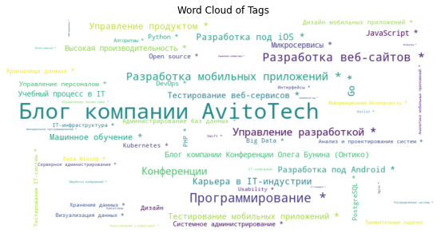

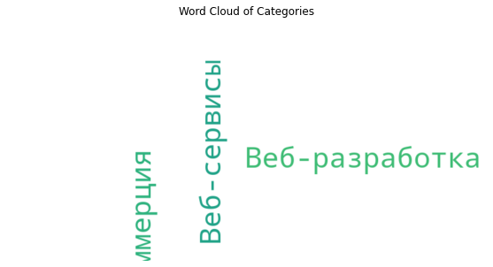

```python
from collections import Counter
# Создаем облако тегов
tags = df['tags_post'].explode()
tags_counter = Counter(tags)
wordcloud = WordCloud(width=800, height=400, background_color='white').generate_from_frequencies(tags_counter)
plt.figure(figsize=(10, 5))
plt.imshow(wordcloud, interpolation='bilinear')
plt.axis('off')
plt.title('Word Cloud of Tags')
plt.show()

# Создаем облако категорий
categories = df['category_list_company'].explode()
categories_counter = Counter(categories)
wordcloud = WordCloud(width=800, height=400, background_color='white').generate_from_frequencies(categories_counter)
plt.figure(figsize=(10, 5))
plt.imshow(wordcloud, interpolation='bilinear')
plt.axis('off')
plt.title('Word Cloud of Categories')
plt.show()
```

```python
!pip install pymorphy2
```

```python
import pandas as pd
import re
import nltk
from nltk.corpus import stopwords
from pymorphy2 import MorphAnalyzer
```

```python
#Удалены все лишние символы, кроме букв из текстов публикаций
def remove_special_chars(text):
    """
    Remove special characters and digits from text.
    """
    return re.sub(r'[^а-яА-Я\s]', '', text)

#Удалены все стоп-слова в тектах публикаций
def remove_stopwords(text):
    """
    Remove stop words from text.
    """
    stop_words = stopwords.words('russian')
    return ' '.join([word for word in text.split() if word not in stop_words])

# Выполнена лемматизация текстов публикаций
def lemmatize(text):
    """
    Lemmatize text using pymorphy2.
    """
    morph = MorphAnalyzer()
    return ' '.join([morph.parse(word)[0].normal_form for word in text.split()])
```

```python
# Применяем функцию remove_special_chars() к столбцу с именем 'text_column'
df['text_clear'] = df['text_post'].apply(remove_special_chars)

# Применяем функцию remove_stopwords() к столбцу с именем 'text_column'
df['text_clear'] = df['text_clear'].apply(remove_stopwords)

# Применяем lemmatize() к столбцу с именем 'text_column'
df['text_clear'] = df['text_clear'].apply(lemmatize)
```

```python
import nltk
nltk.download('punkt')  # Загружаем необходимые данные NLTK для токенизации

# Определяем функцию для обозначения русского текста с помощью NLTK
def tokenize_russian_text(text):
    tokens = nltk.word_tokenize(text, language='russian')
    return tokens

# Применяем функцию токенизации к столбцу "текст" во фрейме данных
df['tokens'] = df['text_clear'].apply(tokenize_russian_text)

# Отображаем результирующий фрейм данных
df.head()
```

|  | name_post | difficulty_post | reading_time_post | views_count_post | tags_post | text_post | rating_company | desc_company | category_list_company | about_company | word_count | unique_word_count | stopword_count | text_clear | tokens |
| --- | --- | --- | --- | --- | --- | --- | --- | --- | --- | --- | --- | --- | --- | --- | --- |
| 0 | Mosdroid #6 — отчёт | No label found | 2 | 3.8 | [Блог компании AvitoTech , Разработка мобильны... | Всем привет! Публикуем отчёт со встречи сообщ... | \n 192.79\n | У нас живут ваши объявления | [\n Веб-разработка\n ,... | Мы команда инженеров Авито. В блоге рассказыва... | 354 | 261 | 97 | весь привет публиковать отчта встреча сообщест... | [весь, привет, публиковать, отчта, встреча, со... |
| 1 | Материалы с митапа для аналитиков: роль аналит... | No label found | 2 | 2.4 | [Блог компании AvitoTech , Повышение конверсии... | Недавно прошёл наш митап для аналитиков, а зн... | \n 192.79\n | У нас живут ваши объявления | [\n Веб-разработка\n ,... | Мы команда инженеров Авито. В блоге рассказыва... | 376 | 255 | 82 | недавно прошлый наш митапа аналитик значит пор... | [недавно, прошлый, наш, митапа, аналитик, знач... |
| 2 | Материалы PaaS-митапа: как платформа улучшает ... | No label found | 2 | 2 | [Блог компании AvitoTech , Системное администр... | Platform as a Service в Авито — это набор про... | \n 192.79\n | У нас живут ваши объявления | [\n Веб-разработка\n ,... | Мы команда инженеров Авито. В блоге рассказыва... | 354 | 231 | 83 | авить это набор проработать решение который по... | [авить, это, набор, проработать, решение, кото... |
| 3 | Мутационное тестирование: опыт внедрения на 15... | No label found | 13 | 9.7 | [Блог компании AvitoTech , Тестирование IT-сис... | Привет, Хабр! Меня зовут Александр, я разрабо... | \n 192.79\n | У нас живут ваши объявления | [\n Веб-разработка\n ,... | Мы команда инженеров Авито. В блоге рассказыва... | 3115 | 1644 | 990 | привет хабра я звать александр разработчик юни... | [привет, хабра, я, звать, александр, разработч... |
| 4 | Масло и водка: как мы избавляем ноутбуки от ст... | No label found | 5 | 63 | [Блог компании AvitoTech , Ноутбуки ] | В Авито все работают на ноутбуках. Так удобне... | \n 192.79\n | У нас живут ваши объявления | [\n Веб-разработка\n ,... | Мы команда инженеров Авито. В блоге рассказыва... | 970 | 618 | 309 | в авить работать ноутбук так удобный заниматьс... | [в, авить, работать, ноутбук, так, удобный, за... |

```python
!python3 -m spacy download ru_core_news_sm
!pip3 install https://github.com/explosion/spacy-models/releases/download/en_core_web_sm-2.2.0/en_core_web_sm-2.2.0.tar.gz
```

```python
pip install -U spacy
```

```python
!python -m spacy download ru_core_news_sm
!pip3 install https://github.com/explosion/spacy-models/releases/download/en_core_web_sm-2.2.0/en_core_web_sm-2.2.0.tar.gz
```

```python
import spacy
nlp = spacy.load("ru_core_news_sm")
```

```python
nltk.download('stopwords');
```

```python
import spacy
import pandas as pd
import nltk
from nltk.corpus import stopwords
from nltk.stem.porter import PorterStemmer
# Загружаем данные в dataframe
# Определяем функцию для выполнения тегов частей речи и выделения значимых частей речи
def highlight_pos(text):
    doc = nlp(text)
    highlighted_text = ""
    for token in doc:
        if token.pos_ in ["NOUN", "VERB"]:   # Определяем значимые части речи
            highlighted_text += f"{token.text} " # Добавляем HTML-теги для выделения
    return highlighted_text

# Применяем функцию к столбцу маркированного текста во фрейме данных

df["highlighted_text"] = df["text_clear"].apply(highlight_pos)

# Распечатываем обновленный фрейм данных
df.head()
```

|  | name_post | difficulty_post | reading_time_post | views_count_post | tags_post | text_post | rating_company | desc_company | category_list_company | about_company | word_count | unique_word_count | stopword_count | text_clear | tokens | highlighted_text |
| --- | --- | --- | --- | --- | --- | --- | --- | --- | --- | --- | --- | --- | --- | --- | --- | --- |
| 0 | Mosdroid #6 — отчёт | No label found | 2 | 3.8 | [Блог компании AvitoTech , Разработка мобильны... | Всем привет! Публикуем отчёт со встречи сообщ... | \n 192.79\n | У нас живут ваши объявления | [\n Веб-разработка\n ,... | Мы команда инженеров Авито. В блоге рассказыва... | 354 | 261 | 97 | весь привет публиковать отчта встреча сообщест... | [весь, привет, публиковать, отчта, встреча, со... | привет публиковать отчта встреча сообщество пр... |
| 1 | Материалы с митапа для аналитиков: роль аналит... | No label found | 2 | 2.4 | [Блог компании AvitoTech , Повышение конверсии... | Недавно прошёл наш митап для аналитиков, а зн... | \n 192.79\n | У нас живут ваши объявления | [\n Веб-разработка\n ,... | Мы команда инженеров Авито. В блоге рассказыва... | 376 | 255 | 82 | недавно прошлый наш митапа аналитик значит пор... | [недавно, прошлый, наш, митапа, аналитик, знач... | митапа аналитик значит пора делиться презентац... |
| 2 | Материалы PaaS-митапа: как платформа улучшает ... | No label found | 2 | 2 | [Блог компании AvitoTech , Системное администр... | Platform as a Service в Авито — это набор про... | \n 192.79\n | У нас живут ваши объявления | [\n Веб-разработка\n ,... | Мы команда инженеров Авито. В блоге рассказыва... | 354 | 231 | 83 | авить это набор проработать решение который по... | [авить, это, набор, проработать, решение, кото... | авить набор проработать решение позволять разр... |
| 3 | Мутационное тестирование: опыт внедрения на 15... | No label found | 13 | 9.7 | [Блог компании AvitoTech , Тестирование IT-сис... | Привет, Хабр! Меня зовут Александр, я разрабо... | \n 192.79\n | У нас живут ваши объявления | [\n Веб-разработка\n ,... | Мы команда инженеров Авито. В блоге рассказыва... | 3115 | 1644 | 990 | привет хабра я звать александр разработчик юни... | [привет, хабра, я, звать, александр, разработч... | привет хабра звать являться центр экспертиза к... |
| 4 | Масло и водка: как мы избавляем ноутбуки от ст... | No label found | 5 | 63 | [Блог компании AvitoTech , Ноутбуки ] | В Авито все работают на ноутбуках. Так удобне... | \n 192.79\n | У нас живут ваши объявления | [\n Веб-разработка\n ,... | Мы команда инженеров Авито. В блоге рассказыва... | 970 | 618 | 309 | в авить работать ноутбук так удобный заниматьс... | [в, авить, работать, ноутбук, так, удобный, за... | авить работать ноутбук удобный заниматься зада... |

```python
pip install -U gensim
```

```python
pip install --upgrade numpy
```

# Начало выполнения заданий модуля Б

# Векторизация

```python
import pandas as pd
from sklearn.feature_extraction.text import CountVectorizer


# Create a CountVectorizer object
vectorizer = CountVectorizer()

# Fit the vectorizer to the text data
vectorizer.fit(df['text_clear'])
```

```
CountVectorizer()
```

# Поиск ключевых слов/n-грамм. Векторизация текстов

Существует несколько способов поиска ключевых слов или n-грамм в текстовых данных. Вот три распространенных метода:

Регулярные выражения. Регулярные выражения — это мощный инструмент для поиска и обработки текста. Они позволяют искать шаблоны в текстовых данных, которые могут включать ключевые слова или n-граммы. Например, вы можете искать все экземпляры слова «кошка» в текстовом файле, используя регулярное выражение \bcat\b.

Мешок слов: модель мешка слов — это простой способ представления текстовых данных в виде вектора частоты слов. Вы можете использовать эту модель для поиска ключевых слов или n-грамм, ища наличие определенных слов или комбинаций слов в векторе. Например, вы можете искать все документы, содержащие слова «кошка» и слово «собака», используя модель мешка слов.

Модели n-грамм: Модель n-грамм — это статистическая языковая модель, которая предсказывает вероятность слова с учетом его предыдущих n-1 слов. Вы можете использовать эту модель для поиска n-грамм, ища наличие определенных n-грамм в текстовых данных. Например, вы можете искать все вхождения фразы «машинное обучение» в корпусе документов, используя модель n-грамм.

Использование статистических методов для обработки текстовых данных и выделения биграмм и триграмм имеет несколько преимуществ:

Улучшение качества обработки текстовых данных: выделение биграмм и триграмм позволяет захватить более глубокий контекст и смысл в текстовых данных, что может привести к более точным и полезным результатам при анализе текста.

Увеличение размера словаря: выделение биграмм и триграмм увеличивает размер словаря, что может улучшить качество моделей, основанных на текстовых данных, таких как моделирование тем или анализ тональности.

Улучшение скорости обработки: использование статистических методов для выделения биграмм и триграмм может ускорить обработку текстовых данных, поскольку это может уменьшить количество уникальных слов, которые необходимо обрабатывать.

Легкость в использовании: библиотеки, такие как Gensim, предоставляют простой и удобный способ выделения биграмм и триграмм в текстовых данных, что делает этот подход доступным и легким в использовании для широкого круга пользователей.

Модели n-грамм

```python
# Импортируем необходимые библиотеки
import spacy
from nltk.corpus import stopwords
from gensim.models.phrases import Phrases

# Преобразуем объект WordList в список предложений
sentences = list(df['text_clear'])

# Создаем модели биграмм и триграмм с помощью функции Phrases из библиотеки Gensim
# min_count и threshold - параметры, которые контролируют, как часто должна встречаться фраза в тексте, чтобы быть рассмотренной как биграмма или триграмма
bigram = Phrases(sentences, min_count=5, threshold=100)
trigram = Phrases(bigram[sentences], min_count=5, threshold=100)

# Применяем модели к предложениям
for idx in range(len(sentences)):
    for token in bigram[sentences[idx]]:
        if '_' in token:
            # Токен - биграмма, добавляем в предложение
            sentences[idx].append(token)
    for token in trigram[bigram[sentences[idx]]]:
        if '_' in token:
               # Токен - триграмма, добавляем в предложение
            sentences[idx].append(token)
# Обновить столбец text_post предварительно обработанным текстом
df['text_bigram_trigram'] = sentences
```

этот код использует библиотеки Natural Language Toolkit (nltk) и Gensim для предварительной обработки текстовых данных в столбце pandas DataFrame с именем text_clear. Вот предпринимаемые шаги:

Преобразовывает столбец text_clear в список предложений.

Создавает модели биграмм и триграмм с помощью функции Phrases от Gensim, которая обнаруживает общие фразы (биграммы и триграммы) в текстовых данных.

Применяет модели биграммы и триграммы к каждому предложению в списке предложений, обнаруживая и добавляя к предложению любые токены биграммы или триграммы.

Конечным результатом является список предварительно обработанных предложений, которые были преобразованы для включения токенов биграммы и триграммы. Эти маркеры могут помочь получить больше контекста и смысла в текстовых данных, что может быть полезно для последующих задач, таких как моделирование темы или анализ тональности.

модель мешка слов

```python
bow_matrix = vectorizer.transform(df['text_clear'])

# Вывод на экран признаков и матрицы мешка слов
print("Признаки:", vectorizer.get_feature_names())
print("Матрица мешка слов:\n", bow_matrix.toarray())
```

[output not shown]

Регулярные выражения

```python
import pandas as pd
from sklearn.feature_extraction.text import CountVectorizer



# Search for the keyword "cat" in the first document
if "Победа" in df.columns:
    doc_index = 0
    cat_count = df.loc[doc_index, "Победа"]
    print(f"Слово 'Победа' встречается {cat_count} столько раз в документе {doc_index+1}.")
else:
    print("Слово 'Победа' не встречается.")
```

```
Слово 'Победа' не встречается.
```

```python
df.head()
```

|  | name_post | difficulty_post | reading_time_post | views_count_post | tags_post | text_post | rating_company | desc_company | category_list_company | about_company | word_count | unique_word_count | stopword_count | text_clear | tokens | highlighted_text | text_bigram_trigram |
| --- | --- | --- | --- | --- | --- | --- | --- | --- | --- | --- | --- | --- | --- | --- | --- | --- | --- |
| 0 | Mosdroid #6 — отчёт | No label found | 2 | 3.8 | [Блог компании AvitoTech , Разработка мобильны... | Всем привет! Публикуем отчёт со встречи сообщ... | \n 192.79\n | У нас живут ваши объявления | [\n Веб-разработка\n ,... | Мы команда инженеров Авито. В блоге рассказыва... | 354 | 261 | 97 | весь привет публиковать отчта встреча сообщест... | [весь, привет, публиковать, отчта, встреча, со... | привет публиковать отчта встреча сообщество пр... | весь привет публиковать отчта встреча сообщест... |
| 1 | Материалы с митапа для аналитиков: роль аналит... | No label found | 2 | 2.4 | [Блог компании AvitoTech , Повышение конверсии... | Недавно прошёл наш митап для аналитиков, а зн... | \n 192.79\n | У нас живут ваши объявления | [\n Веб-разработка\n ,... | Мы команда инженеров Авито. В блоге рассказыва... | 376 | 255 | 82 | недавно прошлый наш митапа аналитик значит пор... | [недавно, прошлый, наш, митапа, аналитик, знач... | митапа аналитик значит пора делиться презентац... | недавно прошлый наш митапа аналитик значит пор... |
| 2 | Материалы PaaS-митапа: как платформа улучшает ... | No label found | 2 | 2 | [Блог компании AvitoTech , Системное администр... | Platform as a Service в Авито — это набор про... | \n 192.79\n | У нас живут ваши объявления | [\n Веб-разработка\n ,... | Мы команда инженеров Авито. В блоге рассказыва... | 354 | 231 | 83 | авить это набор проработать решение который по... | [авить, это, набор, проработать, решение, кото... | авить набор проработать решение позволять разр... | авить это набор проработать решение который по... |
| 3 | Мутационное тестирование: опыт внедрения на 15... | No label found | 13 | 9.7 | [Блог компании AvitoTech , Тестирование IT-сис... | Привет, Хабр! Меня зовут Александр, я разрабо... | \n 192.79\n | У нас живут ваши объявления | [\n Веб-разработка\n ,... | Мы команда инженеров Авито. В блоге рассказыва... | 3115 | 1644 | 990 | привет хабра я звать александр разработчик юни... | [привет, хабра, я, звать, александр, разработч... | привет хабра звать являться центр экспертиза к... | привет хабра я звать александр разработчик юни... |
| 4 | Масло и водка: как мы избавляем ноутбуки от ст... | No label found | 5 | 63 | [Блог компании AvitoTech , Ноутбуки ] | В Авито все работают на ноутбуках. Так удобне... | \n 192.79\n | У нас живут ваши объявления | [\n Веб-разработка\n ,... | Мы команда инженеров Авито. В блоге рассказыва... | 970 | 618 | 309 | в авить работать ноутбук так удобный заниматьс... | [в, авить, работать, ноутбук, так, удобный, за... | авить работать ноутбук удобный заниматься зада... | в авить работать ноутбук так удобный заниматьс... |

# Кластеризация

Данный код на языке Python использует библиотеки Matplotlib, scikit-learn и TSNE для кластеризации текстовых данных и их визуализации в двумерном пространстве с помощью метода t-SNE.

Первая строка импортирует необходимые библиотеки.

Далее, используется класс TfidfVectorizer из библиотеки scikit-learn для преобразования текстовых данных в векторное представление на основе TF-IDF.

Затем, используются три различных алгоритма кластеризации: K-means, иерархическая кластеризация и DBSCAN. Для K-means и иерархической кластеризации задаётся количество кластеров k=5.

Для визуализации кластеров в двумерном пространстве используется метод t-SNE.

Кластеризация - это процесс группировки объектов на основе их сходства. Существует множество алгоритмов кластеризации, и каждый из них имеет свои особенности и применения. Вот некоторые из наиболее распространенных алгоритмов кластеризации с примерами кода и визуализацией:

--K-средних (K-means)

K-средних - это один из самых популярных алгоритмов кластеризации. Он основан на минимизации суммарного квадрата расстояний между точками и центрами кластеров. Вот пример кода на Python для кластеризации данных методом K-средних

--DBSCAN

DBSCAN - это алгоритм кластеризации, который основан на плотности точек. Он позволяет идентифицировать выбросы и определять кластеры произвольной формы. Вот пример кода на Python для кластеризации данных методом DBSCAN:

--Иерархическая кластеризация

Иерархическая кластеризация - это алгоритм кластеризации, который строит иерархическую структуру кластеров. Он может быть агломеративным (начинает с каждой точки в отдельном кластере и объединяет их) или дивизионным (начинает с одного кластера и разделяет его на более мелкие). Вот пример кода на Python для кластеризации данных методом иерархической кластеризации:

```python
import matplotlib.pyplot as plt
from sklearn.feature_extraction.text import TfidfVectorizer
from sklearn.cluster import KMeans, AgglomerativeClustering, DBSCAN
from sklearn.manifold import TSNE

# Преобразование текстовых данных в векторное представление
vectorizer = TfidfVectorizer()
X = vectorizer.fit_transform(df['text_bigram_trigram'])

# Выполнение кластеризации K-средних
k = 5  # Число кластеров
kmeans = KMeans(n_clusters=k, random_state=0)
kmeans_labels = kmeans.fit_predict(X)

# Выполнение иерархической кластеризации
hierarchical = AgglomerativeClustering(n_clusters=k)
hierarchical_labels = hierarchical.fit_predict(X.toarray())  # Convert sparse matrix to dense array

# Выполнение кластеризации DBSCAN
dbscan = DBSCAN(eps=0.5, min_samples=5)
dbscan_labels = dbscan.fit_predict(X)

# Применить t-SNE для визуализации
tsne = TSNE(n_components=2, random_state=0)
X_tsne = tsne.fit_transform(X.toarray())  # Convert sparse matrix to dense array

# Постройте результаты
plt.scatter(X_tsne[:, 0], X_tsne[:, 1], c=kmeans_labels, cmap='viridis')
plt.title('K-means Clustering (t-SNE)')
plt.show()

plt.scatter(X_tsne[:, 0], X_tsne[:, 1], c=hierarchical_labels, cmap='viridis')
plt.title('Hierarchical Clustering (t-SNE)')
plt.show()

plt.scatter(X_tsne[:, 0], X_tsne[:, 1], c=dbscan_labels, cmap='viridis')
plt.title('DBSCAN Clustering (t-SNE)')
plt.show()
```

[output not shown]

[output cut: 39 more lines]

[output not shown]